# a3

**Assignment 3**

Gurjot Singh(B00811724) Bhavneet Kaur Sachdeva(B00809769)

Gurjot SIngh (Q1 and Q5) Bhavneet Kaur (Q2 and Q4)

**Q1** To find all vessels that visited a port and to find all AIS messages to those ports

Referenced majorly from Lab Tutorial on spatio-temporal data

```python
import geopandas as gpd
```

```python
import numpy as np
import pandas as pd
from shapely.geometry import Point
import shapely
import missingno as msn
import seaborn as sns
import matplotlib.pyplot as plt
```

```python
% matplotlib inline
```

```python
df=pd.read_csv('AISData.csv')
df.rename(columns={'location.coordinates.0':'x','location.coordinates.1':'y'},inplace=True)
df
```

|  | Unnamed: 0 | event_time | x | y | position_accuracy | mmsi | sog | cog |
| --- | --- | --- | --- | --- | --- | --- | --- | --- |
| 0 | 0 | 2019-04-11T09:47:30.153Z | -63.556082 | 44.624835 | 0.0 | 316013808 | 3.0 | 319.500000 |
| 1 | 1 | 2019-04-11T09:47:27.273Z | -63.556053 | 44.624817 | 0.0 | 316013808 | 3.0 | 320.700012 |
| 2 | 2 | 2019-04-11T09:47:34.340Z | -63.556138 | 44.624868 | 0.0 | 316013808 | 2.9 | 319.500000 |
| 3 | 3 | 2019-04-11T09:47:37.087Z | -63.556187 | 44.624898 | 0.0 | 316013808 | 3.0 | 319.799988 |
| 4 | 4 | 2019-04-19T09:52:19.358Z | -63.555998 | 44.624883 | 0.0 | 316013808 | 3.2 | 337.200012 |
| 5 | 5 | 2019-04-19T09:52:19.358Z | -63.555998 | 44.624883 | 0.0 | 316013808 | 3.2 | 337.200012 |
| 6 | 6 | 2019-05-25T19:40:53.826Z | -63.555967 | 44.624998 | 0.0 | 316013808 | 1.5 | 168.399994 |
| 7 | 7 | 2019-05-21T21:39:50.762Z | -63.555977 | 44.625048 | 0.0 | 316013808 | 4.3 | 134.600006 |
| 8 | 8 | 2019-04-09T10:13:59.833Z | -63.555918 | 44.625118 | 0.0 | 316013808 | 3.9 | 312.399994 |
| 9 | 9 | 2019-04-09T10:13:55.860Z | -63.555845 | 44.625072 | 0.0 | 316013808 | 4.3 | 310.600006 |
| 10 | 10 | 2019-04-09T10:13:54.047Z | -63.555810 | 44.625047 | 0.0 | 316013808 | 4.5 | 309.600006 |
| 11 | 11 | 2019-04-09T10:13:49.593Z | -63.555695 | 44.624980 | 0.0 | 316013808 | 4.6 | 307.500000 |
| 12 | 12 | 2019-05-21T21:39:42.310Z | -63.555745 | 44.624903 | 0.0 | 316013808 | 4.5 | 131.199997 |
| 13 | 13 | 2019-06-15T18:04:14.818Z | -63.555600 | 44.624910 | 0.0 | 316013808 | 2.6 | 324.200012 |
| 14 | 14 | 2019-05-23T09:47:19.324Z | -63.555537 | 44.624837 | 0.0 | 316013808 | 2.5 | 323.799988 |
| 15 | 15 | 2019-06-22T10:53:38.331Z | -63.555565 | 44.624832 | 0.0 | 316013808 | 6.5 | 0.400000 |
| 16 | 16 | 2019-05-23T09:47:15.772Z | -63.555495 | 44.624795 | 0.0 | 316013808 | 2.5 | 323.000000 |
| 17 | 17 | 2019-06-15T18:04:04.933Z | -63.555500 | 44.624802 | 0.0 | 316013808 | 2.7 | 324.399994 |
| 18 | 18 | 2019-05-23T09:47:12.839Z | -63.555442 | 44.624758 | 0.0 | 316013808 | 2.6 | 323.799988 |
| 19 | 19 | 2019-04-09T10:13:35.967Z | -63.555375 | 44.624805 | 0.0 | 316013808 | 4.0 | 309.100006 |
| 20 | 20 | 2019-06-22T10:53:41.051Z | -63.555507 | 44.624920 | 0.0 | 316013808 | 6.5 | 7.200000 |
| 21 | 21 | 2019-04-09T10:13:46.606Z | -63.555622 | 44.624938 | 0.0 | 316013808 | 4.5 | 306.100006 |
| 22 | 22 | 2019-04-06T10:16:43.033Z | -63.555162 | 44.624988 | 0.0 | 316013808 | 2.2 | 7.100000 |
| 23 | 23 | 2019-04-06T10:16:46.046Z | -63.555163 | 44.625035 | 0.0 | 316013808 | 2.5 | 1.600000 |
| 24 | 24 | 2019-04-19T09:34:40.745Z | -63.555073 | 44.625103 | 0.0 | 316013808 | 4.4 | 152.100006 |
| 25 | 25 | 2019-04-06T10:16:55.779Z | -63.555172 | 44.625175 | 0.0 | 316013808 | 3.3 | 2.400000 |
| 26 | 26 | 2019-06-22T10:55:55.851Z | -63.555123 | 44.625197 | 0.0 | 316013808 | 1.7 | 300.600006 |
| 27 | 27 | 2019-06-22T10:55:45.585Z | -63.555025 | 44.625148 | 0.0 | 316013808 | 1.8 | 300.000000 |
| 28 | 28 | 2019-04-19T09:34:30.425Z | -63.555205 | 44.625282 | 0.0 | 316013808 | 4.4 | 154.399994 |
| 29 | 29 | 2019-04-19T09:34:30.456Z | -63.555205 | 44.625282 | 0.0 | 316013808 | 4.4 | 154.399994 |
| ... | ... | ... | ... | ... | ... | ... | ... | ... |
| 766641 | 353456 | 2019-06-11T01:19:45.339Z | -63.549448 | 44.648083 | 0.0 | 316013808 | 0.0 | 148.800003 |
| 766642 | 353457 | 2019-06-11T01:19:54.725Z | -63.549452 | 44.648085 | 0.0 | 316013808 | 0.0 | 148.800003 |
| 766643 | 353458 | 2019-05-28T02:04:03.371Z | -63.549447 | 44.648095 | 0.0 | 316013808 | 0.0 | 232.300003 |
| 766644 | 353459 | 2019-05-28T02:03:53.771Z | -63.549455 | 44.648098 | 0.0 | 316013808 | 0.0 | 232.300003 |
| 766645 | 353460 | 2019-04-06T05:34:50.159Z | -63.549452 | 44.648102 | 0.0 | 316013808 | 0.0 | 241.800003 |
| 766646 | 353461 | 2019-04-06T05:34:41.065Z | -63.549433 | 44.648102 | 0.0 | 316013808 | 0.0 | 241.800003 |
| 766647 | 353462 | 2019-06-16T00:48:14.989Z | -63.549453 | 44.648065 | 0.0 | 316013808 | 0.0 | 103.099998 |
| 766648 | 353463 | 2019-05-23T02:23:53.772Z | -63.549445 | 44.648077 | 0.0 | 316013808 | 0.0 | 185.899994 |
| 766649 | 353464 | 2019-05-28T02:04:23.931Z | -63.549477 | 44.648070 | 0.0 | 316013808 | 0.0 | 232.300003 |
| 766650 | 353465 | 2019-05-25T02:10:52.918Z | -63.549470 | 44.648062 | 0.0 | 316013808 | 0.0 | 174.100006 |
| 766651 | 353466 | 2019-05-24T02:15:03.451Z | -63.549473 | 44.648057 | 0.0 | 316013808 | 0.1 | 92.800003 |
| 766652 | 353467 | 2019-05-25T02:10:43.478Z | -63.549473 | 44.648058 | 0.0 | 316013808 | 0.0 | 174.100006 |
| 766653 | 353468 | 2019-05-28T02:04:32.385Z | -63.549488 | 44.648062 | 0.0 | 316013808 | 0.0 | 232.300003 |
| 766654 | 353469 | 2019-05-25T02:10:32.918Z | -63.549490 | 44.648052 | 0.0 | 316013808 | 0.0 | 174.100006 |
| 766655 | 353470 | 2019-05-29T01:52:33.904Z | -63.549472 | 44.648048 | 0.0 | 316013808 | 0.0 | 238.000000 |
| 766656 | 353471 | 2019-05-25T02:11:02.278Z | -63.549462 | 44.648052 | 0.0 | 316013808 | 0.0 | 174.100006 |
| 766657 | 353472 | 2019-05-29T01:52:21.984Z | -63.549428 | 44.648043 | 0.0 | 316013808 | 0.0 | 238.000000 |
| 766658 | 0 | 2019-06-16T00:48:04.269Z | -63.549400 | 44.648025 | 0.0 | 316013808 | 0.1 | 103.099998 |
| 766659 | 1 | 2019-06-23T10:34:35.505Z | -63.549478 | 44.648010 | 0.0 | 316013808 | 0.0 | 236.100006 |
| 766660 | 2 | 2019-04-14T05:00:10.461Z | -63.549467 | 44.648010 | 0.0 | 316013808 | 0.0 | 229.300003 |
| 766661 | 3 | 2019-05-17T02:43:11.395Z | -63.549447 | 44.648007 | 0.0 | 316013808 | 0.1 | 209.300003 |
| 766662 | 4 | 2019-05-29T01:59:33.302Z | -63.549478 | 44.648003 | 0.0 | 316013808 | 0.0 | 238.000000 |
| 766663 | 5 | 2019-04-06T20:13:40.526Z | -63.549518 | 44.647950 | 0.0 | 316013808 | 0.0 | 31.700001 |
| 766664 | 6 | 2019-06-21T14:56:04.886Z | -63.549497 | 44.647945 | 0.0 | 316013808 | 0.4 | 285.700012 |
| 766665 | 7 | 2019-05-19T21:18:43.579Z | -63.549520 | 44.647925 | 0.0 | 316013808 | 0.0 | 244.899994 |
| 766666 | 8 | 2019-05-19T21:18:02.995Z | -63.549495 | 44.647888 | 0.0 | 316013808 | 0.0 | 244.899994 |
| 766667 | 9 | 2019-05-19T21:17:51.902Z | -63.549513 | 44.647892 | 0.0 | 316013808 | 0.0 | 244.899994 |
| 766668 | 0 | 2019-06-23T16:19:35.025Z | -63.548815 | 44.647857 | 0.0 | 316013808 | 0.0 | 124.699997 |
| 766669 | 1 | 2019-06-23T16:19:41.501Z | -63.548815 | 44.647857 | 0.0 | 316013808 | 0.0 | 124.699997 |
| 766670 | 2 | 2019-06-23T16:19:14.331Z | -63.548968 | 44.647907 | 0.0 | 316013808 | 0.0 | 124.699997 |

766671 rows × 8 columns

```python
gdf = gpd.GeoDataFrame(df.drop(['x', 'y'], axis=1),
                                crs={'init': 'epsg:4326'},
                                geometry=[shapely.geometry.Point(xy) for xy in zip(df.x, df.y)])
```

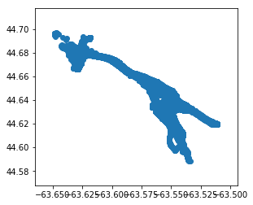

```python
gdf.plot()
```

```python
ports=gpd.read_file('assignment3shapefile.shp')
ports.crs = {'init': 'epsg:3006'}
bylaw=ports.set_index(['port_name'])
print(type(bylaw))
```

```
<class 'geopandas.geodataframe.GeoDataFrame'>
```

Referenced from : http://darribas.org/gds15/content/labs/lab_03.html

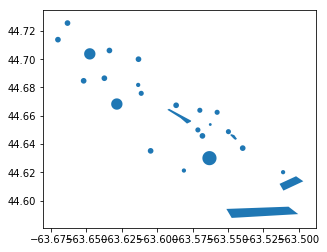

```python
bylaw.plot()
```

```python
cent = bylaw.centroid
```

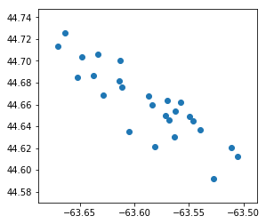

```python
cent.plot()
```

```python
buff = cent.buffer(0.01)
```

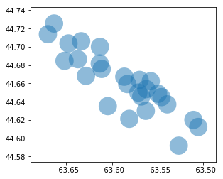

```python
buff.plot(alpha=0.5)
```

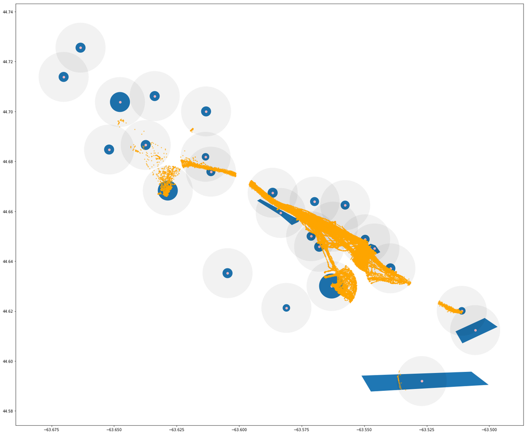

```python
fig,ax = plt.subplots(1, figsize = (25,25))
bylaw.plot(ax=ax)
cent.plot(ax = ax,facecolor = 'pink')
buff.plot(ax = ax,facecolor = 'black',alpha = 0.05)

#http://geopandas.org/reference.html
for i in list(buff):
    gdf.loc[gdf.within(i),:].plot(ax=ax, color='orange', markersize=5, alpha=0.5)
```

**Q2** To color code the ports based on the densty of ais calls

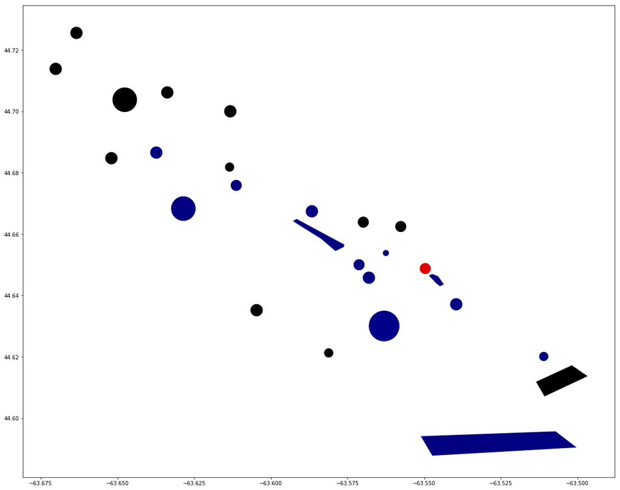

```python
import matplotlib.cm as cm
from matplotlib.colors import Normalize

#Referenced from LAb tutorial and https://stackoverflow.com/questions/8931268/using-colormaps-to-set-color-of-line-in-matplotlib
colors = plt.get_cmap('jet')
cNorm = Normalize(vmin=-1, vmax=1)
fig, ax = plt.subplots(1, figsize= (20,20))
num = gdf.shape[0]
a_list=[]
for g in bylaw.index.values:
    area=bylaw.loc[bylaw.index==g,:]
    aa=area.geometry[0]
    r=gdf.loc[gdf.within(aa),:]
    c=r.shape[0]
    den = c/num
    if den >0:
        area.plot(ax=ax, color = colors(den),legend=True)
    else:
        area.plot(ax=ax, color = 'black',legend=True)
```

**Q4** Temporal chart for port2

```python
gdf['event_time'] = pd.to_datetime(gdf['event_time'])
```

```python
gdf['event_time'] = gdf['event_time'].dt.floor('H')
```

[output not shown]

[output cut: 47 more lines]

```python
area=bylaw.loc[bylaw.index=='port2',:]
aa=area.geometry[0]
r=gdf.loc[gdf.within(aa),:]
#r['event_time'] = r['event_time'].dt.floor('H')
```

```python
L = [g.reset_index(drop=True) for i, g in r.groupby([(gdf['event_time'] - gdf['event_time'][0]).astype('timedelta64[h]')])]
```

```python
r['hour'] = r['event_time'].dt.hour
```

Referenced from : https://stackoverflow.com/questions/17709270/i-want-to-create-a-column-of-value-counts-in-my-pandas-dataframe

```python
r['Counts'] = r.hour.groupby(r.hour).transform('count')
```

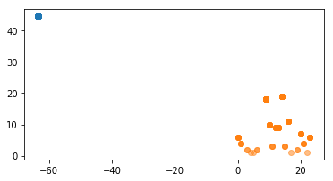

```python
gdf.plot()
plt.scatter(x=r['hour'],y=r['Counts'],alpha=0.5)
```

```python
a = dict(r['hour'].value_counts())
```

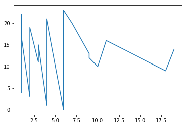

```python
plt.plot(a.values(),a.keys())
```

**Q5** Concept drift detection Referenced from: https://scikit-multiflow.github.io/scikit-multiflow/skmultiflow.drift_detection.html

In this, change is detected as it works on a threshold value and also on observed mean. Hence, if the observed mean increases a threshold value, then change is detected. The smaller the delta, the more sensitive it becomes to change. In this, the default value of delta is 0.005, but it is taken to be 0.0003 to make it more receptive to change. The number of ais calls to the port2 has been used to detect change in this.

```python
from skmultiflow.drift_detection import PageHinkley
phk = PageHinkley(delta=0.0003)
cntList = list(r['Counts'])
for i in range(0,len(cntList)):
    phk.add_element(cntList[i])
    if phk.detected_change():
        print('Change detected in data: ' + str(cntList[i]) + ' - at index: ' + str(i))
```

```
Change detected in data: 19 - at index: 41
Change detected in data: 18 - at index: 70
```